# MACROECONOMIA INTERTEMPORAL I - 2019

# ANTONIO FIORENCIO

## Objetivo

O curso apresenta uma introdução aos métodos modernos de análise das flutuações cíclicas da economia, o ciclo de negócios. Veremos uma introdução aos modelos [DSGE](https://en.wikipedia.org/wiki/Dynamic_stochastic_general_equilibrium) (Equilíbrio Geral Dinâmico Estocástico), baseados nas hipóteses de otimização intertemporal e equilíbrio. Esses modelos, amplamente utilizados na macroeconomia contemporânea, permitem calcular as trajetórias da economia em diversas situações. Para facilitar a transição a partir dos modelos macroeconômicos tradicionais, inicialmente serão discutidos modelos de dois períodos.

## Perguntas

Quais problemas serão estudados? Vejamos alguns exemplos.

### Características empíricas dos ciclos

Queremos entender como as principais variáveis macoreconômicas se comportam ao longo do ciclo econômico. Por exemplo, Uribe & Schmitt-Grohé (2017) indicam, entre várias outras características interesessntes, que: (i) a volatilidade das flutuações cíclicas nos países ricos é cerca da metade daquela dos países pobres e emergentes; (ii) a volatilidade do consumo é inferior à da renda nos países ricos e superior nos países pobres; (iii) as mudanças no ambiente econômico tem efeitos persistentes sobre as variáveis macroeconômicas. O que explica essas características qualitativas e quantitativas?

### Reação aos choques

Como as economias reagem aos choques exógenos? Três exemplos: o apagão de energia em 2001/2002; a greve de caminhoneiro em maio de 2018; o rompimento da brragem de Brumadinho em janeiro de 2019. Esses três eventos tiveram impacto negativo sobre a produtividade da economia. Como poderíamos avaliar seus impactos?

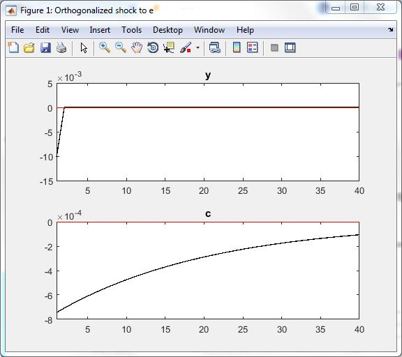

Como você observa, os gráficos indicam que os choques tem um impacto pequeno negativo e temporário sobre o nível de atividade e de consumo da economia. A queda no consumo é menor que na produção, porém mais duradoura. A trajetória do nível de atividade pode parecer óbvia, mas a do consumo, nem tanto. Pode não ser fácil obter esses resultados utilizando, por exemplo, um modelo IS-LM. Além disso, o fato da teoria fornecer um resultado plausível para um problema simples, aumenta nossa confiança em utilizá-la para casos mais complexos.

### Políticas econômicas

Qual o efeito das políticas econômicas? Por exemplo, a figura abaixo mostra a reação da economia brasileira a um aumento no gasto público de acordo com o modelo [SAMBA](https://www.bcb.gov.br/pec/wps/ingl/wps239.pdf) utilizado pelo Banco Central do Brasil para ajudar na formulação da política econômica. A semelhança com a figura anterior é evidente. Em ambos os casos, o objetivo é analisar o comportamento das variáveis econômicas ao longo do tempo em termos quantitativos.

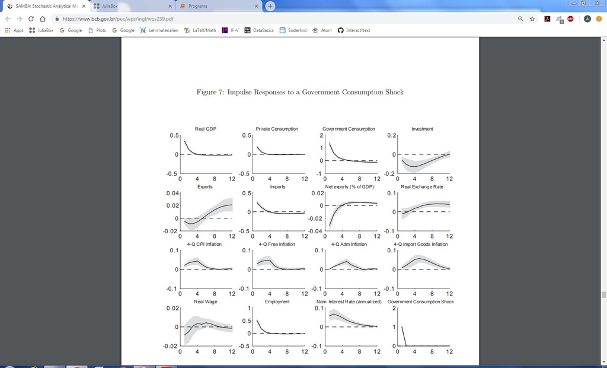

Nada de pânico, esse modelo é complexo demais para ser discutido neste curso, mas o modelo mais simples da primeira figura serve como introdução e será visto no curso. Para quem quer trabalhar com macroeconomia, esse é um esforço útil. As duas tabelas abaixo, extraídas de [Sergi](https://historyofeconomics.org/wp-content/uploads/2017/10/DSGE-standard-narrative.pdf) ilustram o quanto os modelos *DSGE* ganharam espaço entre os bancos centrais do mundo.

[figure not shown]

[figure not shown]

Resumindo, o objetivo do curso é apresentar uma introdução à teoria e ferramentas que inúmeros macoreconomistas profissionais utilizam atualmente para trabalhar.

## Conteúdo

Os tópicos discutidos no curso incluem: consumo, poupança, investimento, oferta de trabalho, conta corrente e política fiscal. Uma introdução à política monetária será vista, se houver tempo. O curso enfatizará a utilização de modelos matemáticos – especificação, resolução e interpretação - e a solução será feita tanto de forma analítica (com lápis e papel) quanto numericamente (com o uso de computador).

### Recursos de informática

As notas de aulas e os programas de computador serão distribuídos, principalmente, como *notebooks* *Jupyter* na linguagem de programação *Julia*. Em alguns casos, usaremos o *Dynare* com *Octave/Matlab*. A utilização dos *notebooks* faz parte do curso. No arquivo *Cp01.html*, disponível na *Conexão* você encontrará instruções básicas para a instalação do *Julia*.

Softwares de referência: [Julia](https://juliacomputing.com/), [Octave](https://www.gnu.org/software/octave/), e [Dynare](http://www.dynare.org/) (gratuitos); [Matlab](https://www.mathworks.com/?s_tid=gn_logo). Não há necessidade de conhecimento prévio de programação ou de séries temporais. Serão distribuídas notas de aula ao longo do curso.

### Critério de aprovação

Duas provas com o mesmo peso. Haverá uma prova substitutiva, cobrindo toda a matéria, **apenas** para quem faltar a uma das provas (P1, P2 ou VS).

## Bibliografia

BLANCHARD, O. [Do DSGE Models Have a Future?](https://piie.com/system/files/documents/pb16-11.pdf) *Policy Brief* 16-11, Peterson Institute for International Economics, 2016.

COCHRANE, J. H. [How Did Paul Krugman Get It So Wrong?](https://faculty.chicagobooth.edu/john.cochrane/research/papers/ecaf_2077.pdf), *mimeo*. 2017.

ELLERY JR., R. G., GOMES V., SASCHIDA, A. [Business Cycles Fluctutations in Brazil](http://bibliotecadigital.fgv.br/ojs/index.php/rbe/article/view/814). *Revista Brasileira de Economia*, 56, 2, 269-308. 2002.

GHATEA, C., PANDEY, R., PATNAIK, I. [Has India emerged? Business cycle stylized facts from a transitioning economy](https://www.isid.ac.in/~cghate/STRECO526.pdf). *Structural Change and Economic Dynamics*, 24, 157–172. 2013.

GRAMINHO, F. M. [A Neoclassical Analysis of the Brazilian "Lost-Decades"](https://www.bcb.gov.br/pec/wps/ingl/wps123.pdf), *Banco Central do Brasil - Working Paper Series # 123*. 2006.

KANCZUK, F., FARIA JR.,F. [Ciclos Reais para a Indústria Brasileira?](http://www.revistas.usp.br/ee/article/view/117647), *Estudos Econômicos - São Paulo*, 30, 3, 335-350.2000.

KEHOE, T. J., PRESCOTT, E. C. (ed) [Great Depressions of the Twentieth Century](https://www.amazon.com/Great-Depressions-Twentieth-Century-Timothy/dp/0978936000). Federal Reserve Bank of Minneapolis. 2007.

KRUGMAN, P. [Two Cheers for Formalism](https://onlinelibrary.wiley.com/doi/abs/10.1111/1468-0297.00378) *The Economic Journal*, 108, 1829-1836. 1998.

KRUGMAN, P. [How Did Economists Get It So Wrong?](https://www.nytimes.com/2009/09/06/magazine/06Economic-t.html) *The New York Times*, 2/9/2009.

KYDLAND, F. E., PRESCOTT, E. C. [The Computational Experiment: An Econometric Tool](https://www.aeaweb.org/articles?id=10.1257/jep.10.1.69); *Journal of Economic Perspectives*, 10,1, 69-85. 1996.

KYDLAND, F. E., ZARAZAGA, C. E. J. M. [Is the Business Cycle of Argentina "Different"?](http://www.finnkydland.com/papers/Is%20the%20Business%20Cycle%20of%20Argentina%20Different.pdf); *Federal Reserve Bank of Dallas Economic Review*. Fourth Quarter. 1997.

MANKIW, N. G. [Real Business Cycles: A New Keynesian Perspective](https://www.aeaweb.org/articles?id=10.1257/jep.3.3.79), *Journal of Economic Perspectives*, 3, 3, 79-90, 1989.

MANKIW, N. G. [A Quick Refresher Course in Macroeconomics](https://scholar.harvard.edu/mankiw/publications/quick-refresher-course-macroeconomics) *Journal of Economic Literature*, XXVIII, 1645-1660. 1990.

MANKIW, N. G. [The Macroeconomist as Scientist and Engineer](https://www.aeaweb.org/articles?id=10.1257/jep.20.4.29), *Journal of Economic Perspectives*, 20, 4, 29-46. 2006.

OHANIAN, L. [The Economic Crisis from a Neoclassical Perspective](http://pubs.aeaweb.org/doi/pdfplus/10.1257/jep.24.4.45), *Journal of Economic Perspectives*, 24, 4, 45-66, 2010.

PLOSSER, C. [Understanding Real Business Cycles](https://www.aeaweb.org/articles?id=10.1257/jep.3.3.51), *Journal of Economic Perspectives*, 3, 3, 51-77, 1989.

REBELO, S. [Real Business Cycle Models: Past, Present and Future](https://onlinelibrary.wiley.com/doi/full/10.1111/j.1467-9442.2005.00405.x), *The Scandinavian Journal of Economics*. 2005.

URIBE, M., SCHMITT-GROHÉ, S. [Open Economy Macroeconomics](https://press.princeton.edu/titles/11032.html), Princeton University Press. 2017.